# resolute bay flux cleaning

Kaj

2024-11-12

# Flux Cleaning

```r
rm(list = ls())

library(data.table)
library(ggplot2)
library(cowplot)
library(openair)
library(plotrix)
library(signal)
library(svMisc)
library(zoo)
library(stringr)
library(plyr)
library(dplyr)
```

Load in eddypro output files

```r
met = fread('C:/Users/klynoe/Documents/resolute_bay/R_outputs/resolut_bay_met_clean.csv')

df = fread('C:/Users/klynoe/Documents/resolute_bay/R_outputs/flux/resolute_bay_fluxes_merged.csv')

df$TIMESTAMP = df$ts

#df = df [!(df$TIMESTAMP <= "2024-07-26 15:00:00"),]

df= merge(df,met,by='TIMESTAMP',all = T)

#check time stamps to ensure we have a complete series
TIMESTAMP = seq(from = min(df$TIMESTAMP), to = max(df$TIMESTAMP),by = 60*30,tz = "UTC")
tsdf = as.data.frame(TIMESTAMP)

df = merge(tsdf,df,by = "TIMESTAMP",all = T)
```

Creates a variable to input a date range for the plots in the flux section of cleaning code. Used to easily change date range for different data sets.

```r
flux_dates <- c("2024-07-25",'2024-10-10')
```

# Initial Clean

## Energy Balance

combine energy fluxes by met and flux components

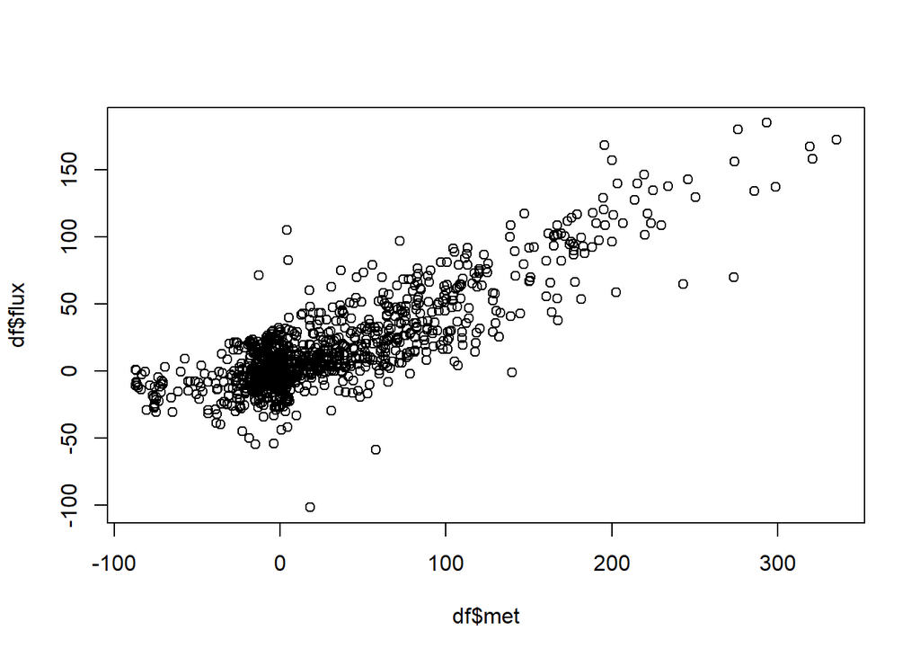

```r
df$met = (df$LWIN_6_14_1_1_1.c + df$SWIN_6_10_1_1_1.c) - (df$LWOUT_6_15_1_1_1.c + df$SWOUT_6_11_1_1_1.c)
df$flux = df$H + df$LE

plot(df$met, df$flux)
```

```r
#add better plot here! with 1:1 line and better axis ratio
```

plot all solar radiation

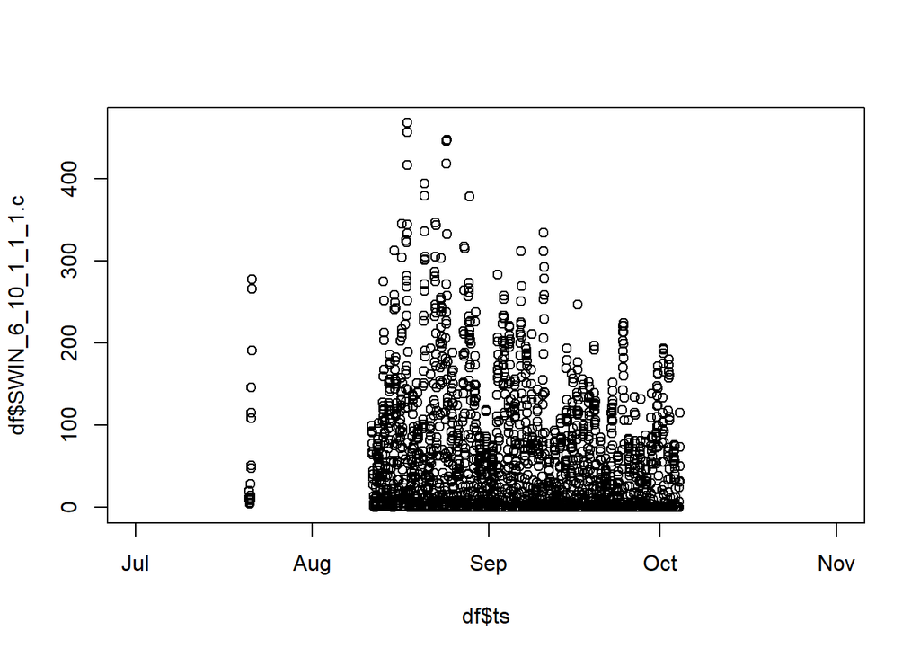

```r
plot(df$ts,df$SWIN_6_10_1_1_1.c)
```

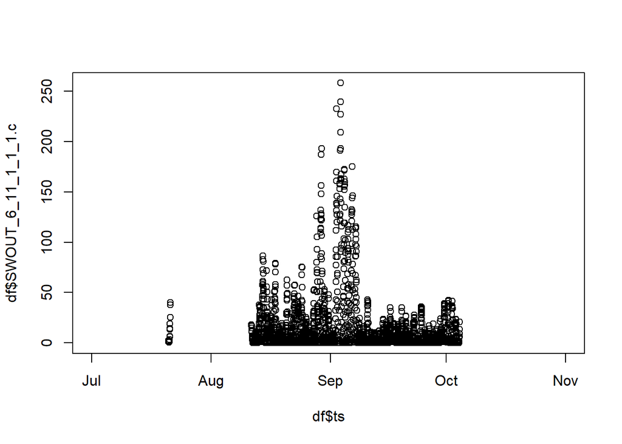

```r
plot(df$ts,df$SWOUT_6_11_1_1_1.c)
```

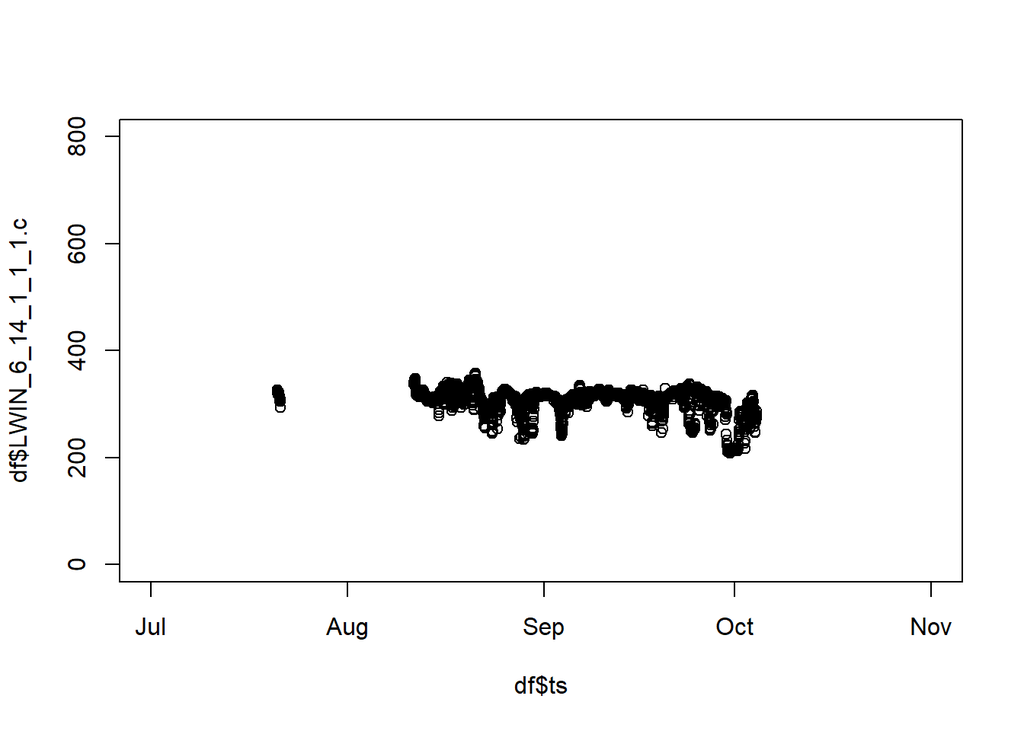

```r
plot(df$ts,df$LWIN_6_14_1_1_1.c,ylim = c(0,800))
```

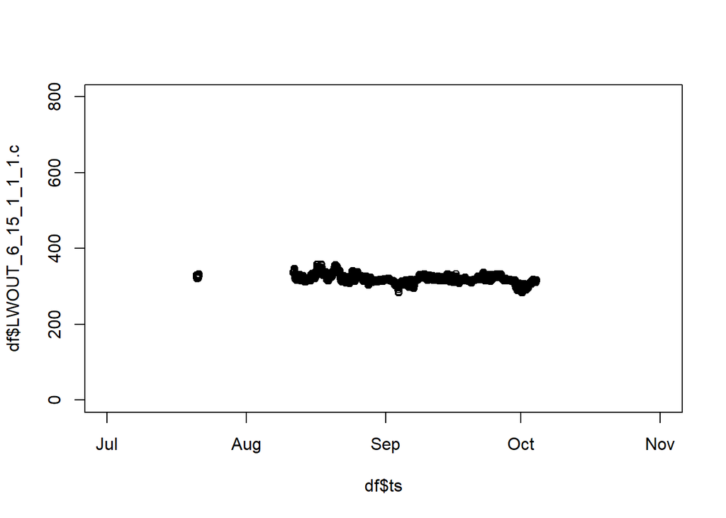

```r
plot(df$ts,df$LWOUT_6_15_1_1_1.c,ylim = c(0,800))
```

create and plot mismatch variable between met and flux

```r
#df$mismatch = df$flux/df$met

#mismatch.limits = ifelse(df$mismatch > 10 & df$mismatch < -10, NA,mismatch.limits)

#mismatch.limits = replace(df$mismatch, df$mismatch < -10 | df$mismatch > 10,NA)


#plot(df$ts,mismatch.limits,)
```

plot energy balance

NEED TO REASSESS OR GET RID OF THIS CHUNK —- removes where the energy balance is off by more than a factor of 10, not sure I like this, mostly removes small fluxes where the factor would have a larger relative mismatch

create new variable _.energy

```r
#Tau.energy  = replace(df$Tau ,abs(df$mismatch)>10,NA)
#H.energy    = replace(df$H   ,abs(df$mismatch)>10,NA)
#LE.energy   = replace(df$LE  ,abs(df$mismatch)>10,NA)
#co2_flux.energy   = replace(df$co2_flux  ,abs(df$mismatch)>10,NA)
#ch4_flux.energy = replace(df$ch4_flux,abs(df$mismatch)>10,NA)
```

## EP QC

filter by the eddypro flags and create new variable _.qc

```r
Tau.qc      = replace(df$Tau,df$qc_Tau == 2,NA)
co2_flux.qc = replace(df$co2_flux,df$qc_co2_flux == 2,NA)
ch4_flux.qc = replace(df$ch4_flux,df$qc_ch4_flux == 2,NA)
LE.qc       = replace(df$LE,df$qc_LE == 2,NA)
H.qc        = replace(df$H,df$qc_H == 2,NA)
```

## Clear Outliers

look for absolute outliers and manually set some absolute limits to remove crazy data

### Tau

Plot Tau Histogram

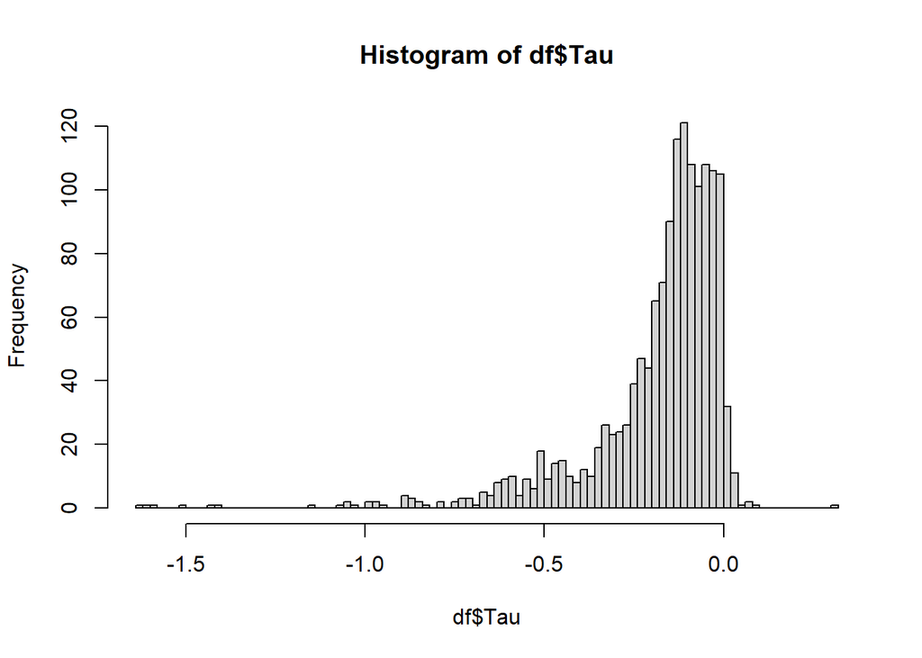

```r
hist(df$Tau,breaks=100)
```

Cut the crazy data and create new variable (Tau.limits)

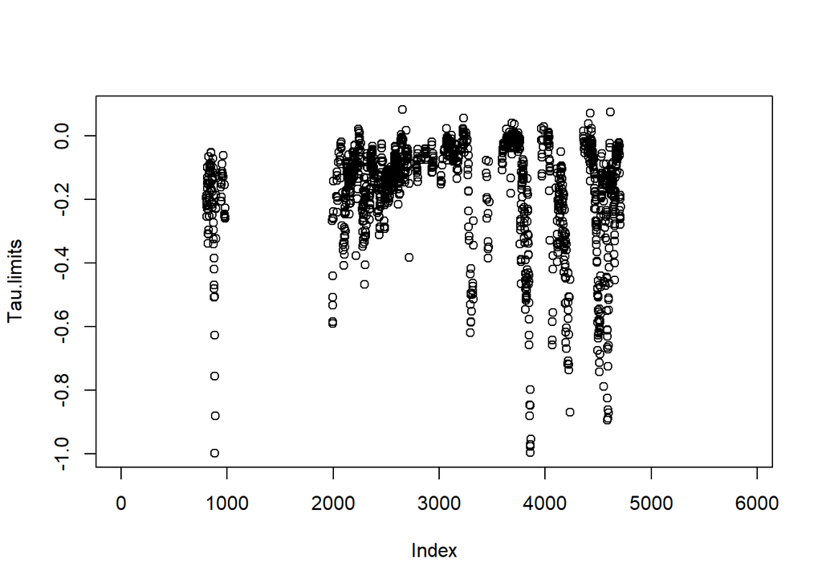

```r
Tau.limits = df$Tau
Tau.limits = replace(df$Tau,df$Tau < -1 | df$Tau > .2,NA)

plot(Tau.limits)
```

### NEE

Plot NEE Histogram and what we might clean

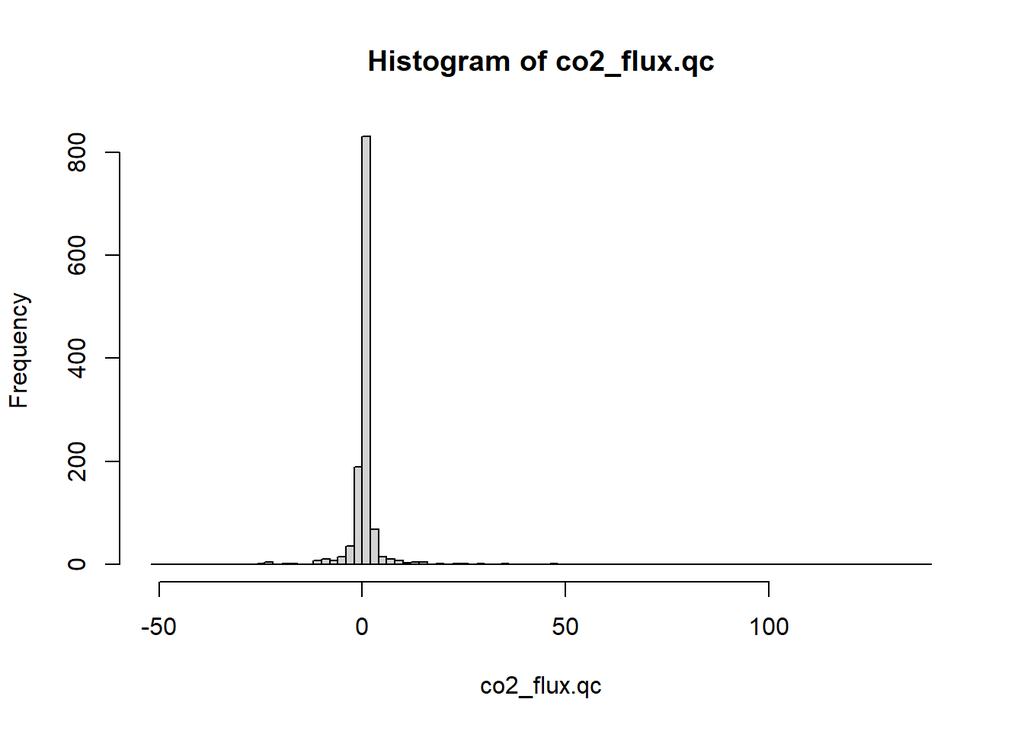

```r
hist(co2_flux.qc,breaks=100)
```

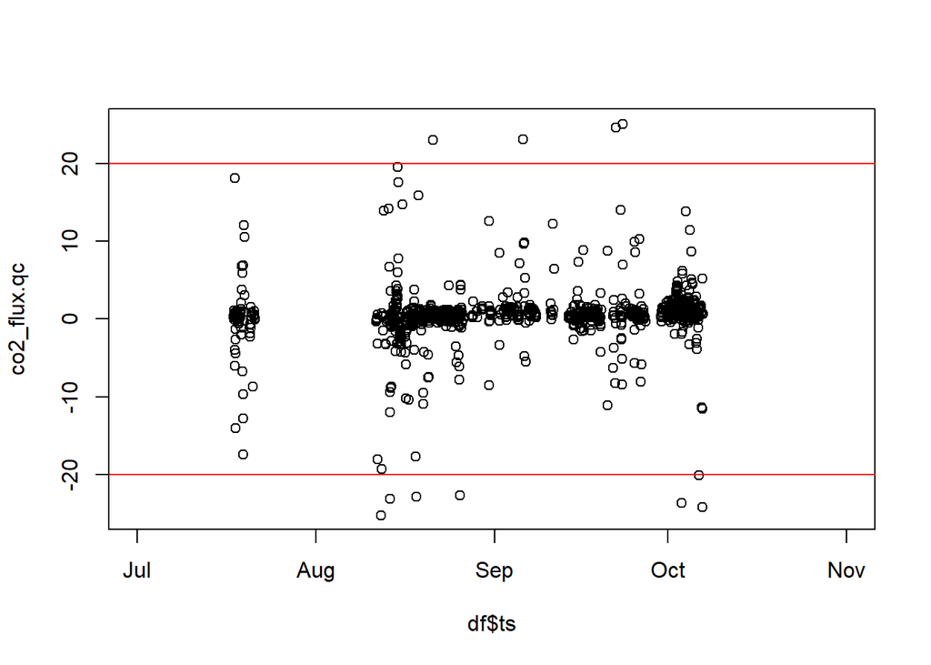

```r
#
plot(df$ts,co2_flux.qc,ylim = c(-25,25));abline(h=20, col= 'red');abline(h=-20, col='red')
```

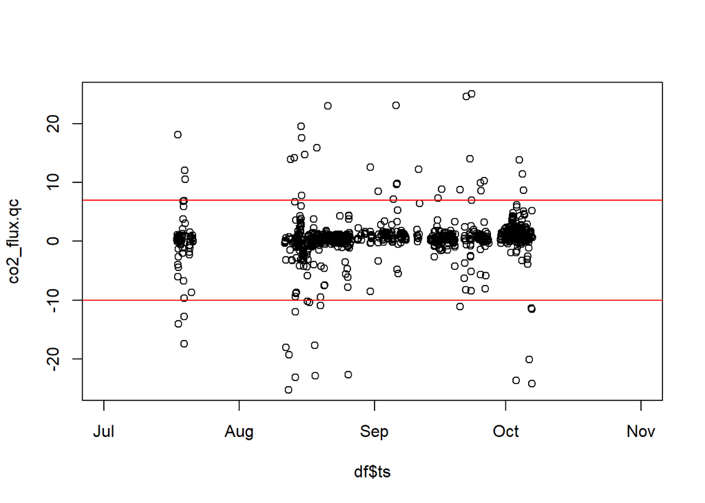

```r
#
plot(df$ts,co2_flux.qc,ylim = c(-25,25));abline(h=7, col= 'red');abline(h=-10, col='red')
```

Clean based on graphs, create new variable (co2_flux.limits), and see cleaned product

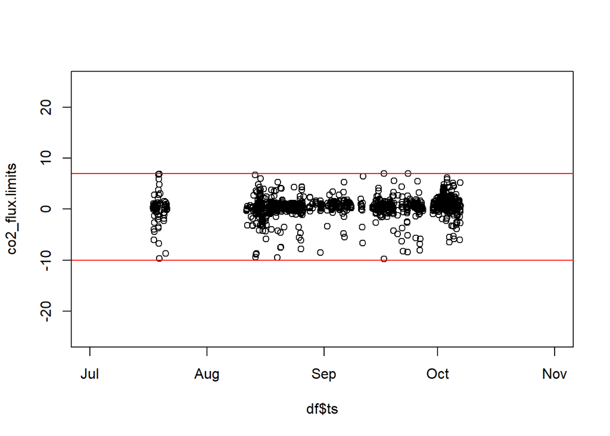

```r
co2_flux.limits = replace(df$co2_flux,(df$co2_flux > 7 | df$co2_flux < -10) & df$TIMESTAMP >= '2024-07-01' | (df$co2_flux > 10 | df$co2_flux < -14),NA)


plot(df$ts,co2_flux.limits,ylim = c(-25,25));abline(h=7, col= 'red');abline(h=-10, col='red')
```

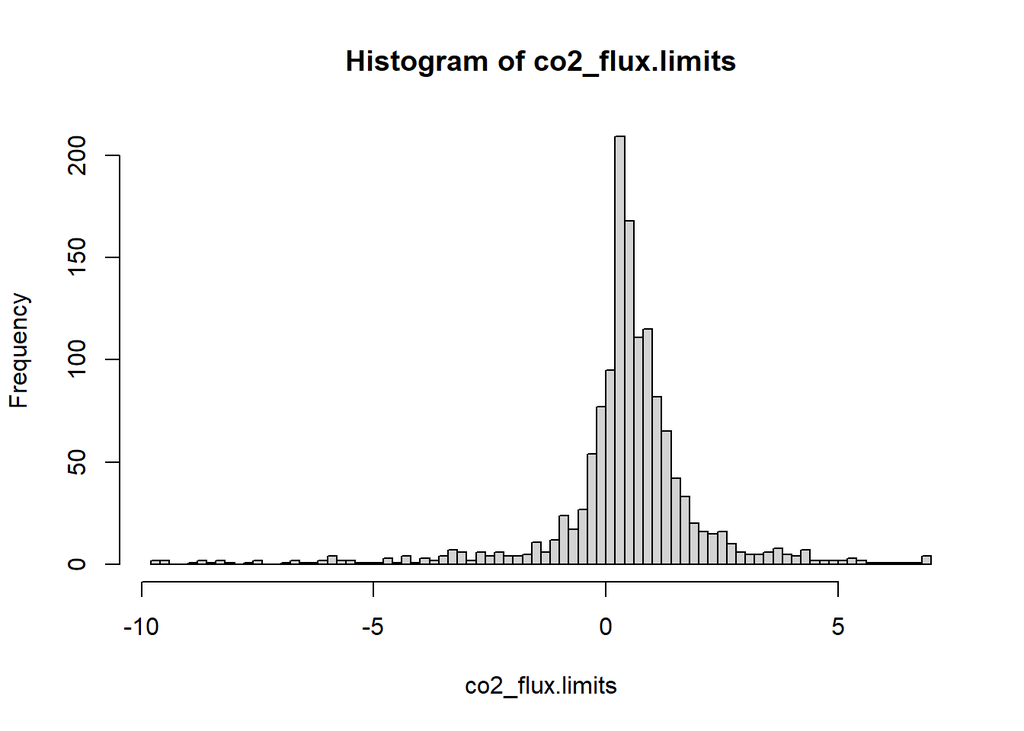

```r
hist(co2_flux.limits,breaks=100)
```

### CH4

Plot CH4 Histogram and what we might clean

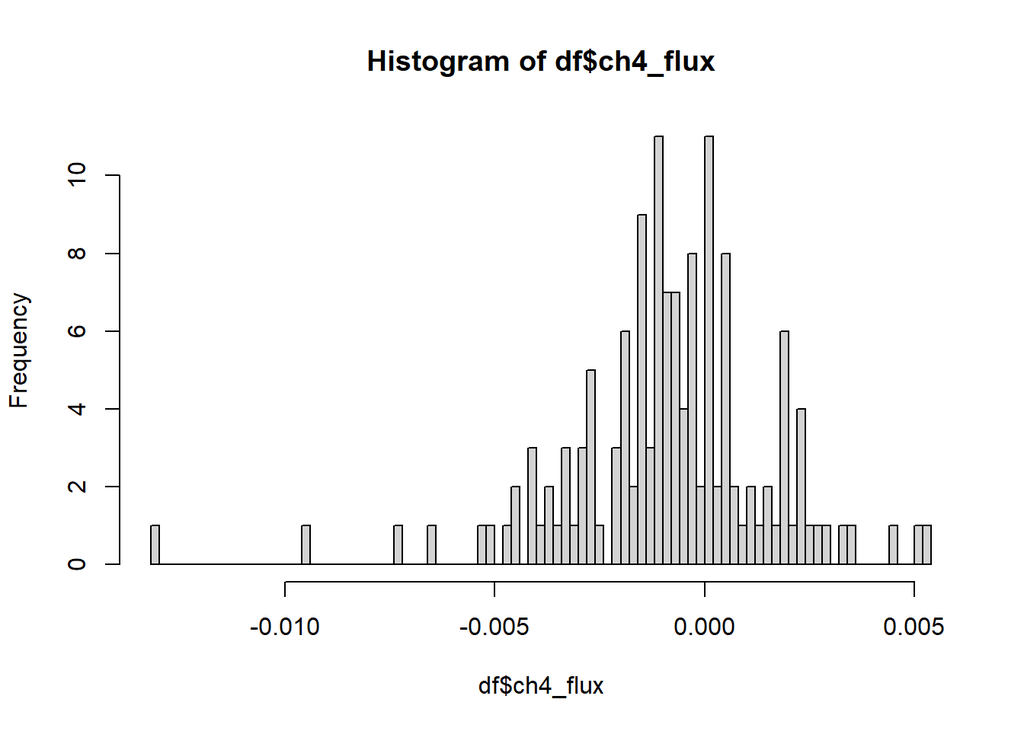

```r
hist(df$ch4_flux,breaks=100)
```

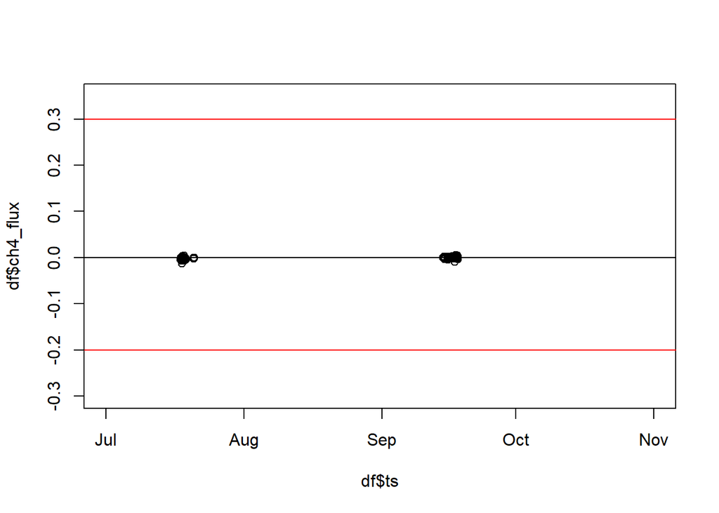

```r
plot(df$ts,df$ch4_flux,ylim = c(-.3,.35));abline(h=.3, col= 'red');abline(h=-.20, col='red'); abline(h=0,col= 'black')
```

Clean based on graphs, create new variable (ch4_flux.limits), and see cleaned product

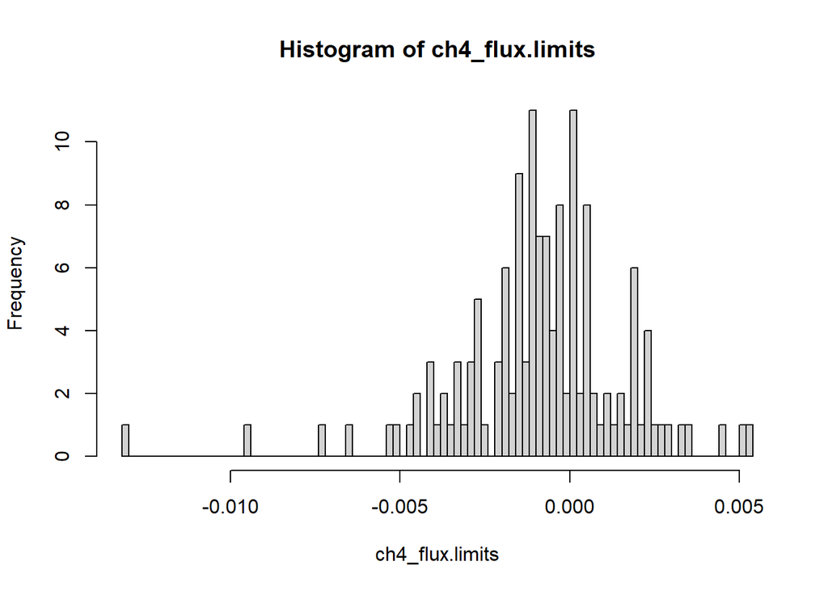

```r
CH4MOLE = ggplot(data = df)+geom_hline(yintercept = 0)+
  geom_point(aes(x=ts,y=ch4_mole_fraction))+
  geom_vline(xintercept = as.POSIXct('2024-7-26 16:30'),col = 'red')+
  geom_vline(xintercept = as.POSIXct('2024-10-21 11:00'),col = 'red')+
  scale_y_continuous(limits = c(0,4))


ch4_flux.limits = df$ch4_flux


hist(ch4_flux.limits,breaks = 100)
```

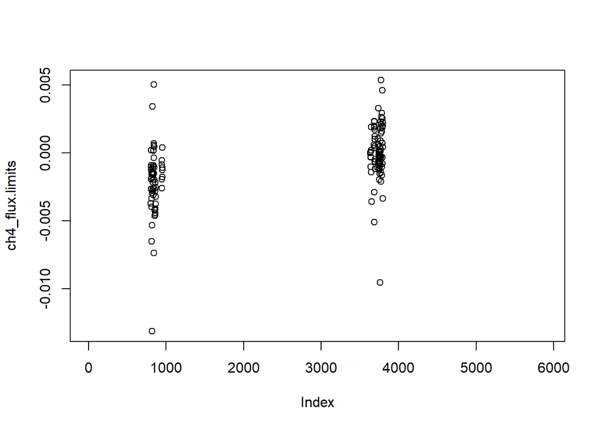

```r
plot(ch4_flux.limits)
```

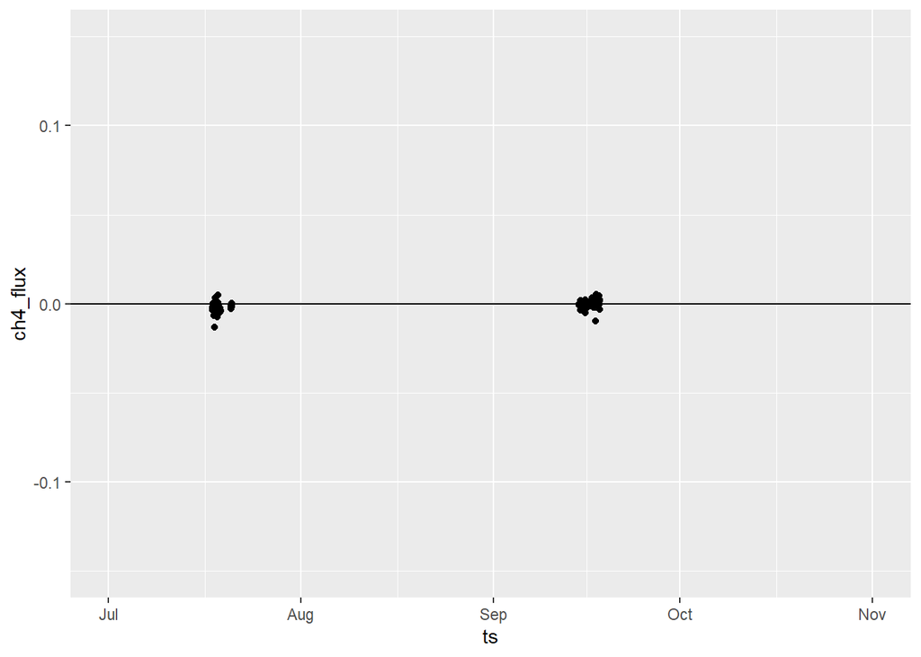

```r
ggplot(data = df)+geom_hline(yintercept = 0)+
  geom_point(aes(x=ts,y=ch4_flux),col = 'red')+
  geom_point(aes(x=ts,y=ch4_flux.limits),col = 'black')+
  scale_y_continuous(limits = c(-.15,.15))
```

### H

Plot H Histogram and what we might clean

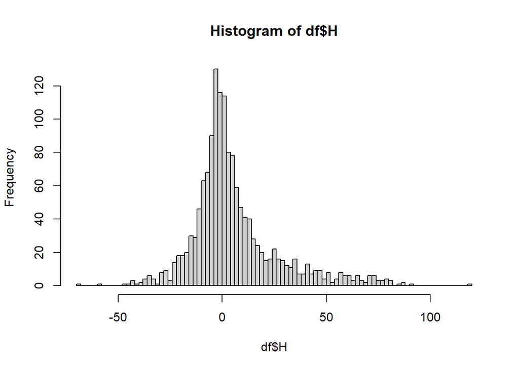

```r
hist(df$H,breaks=100)
```

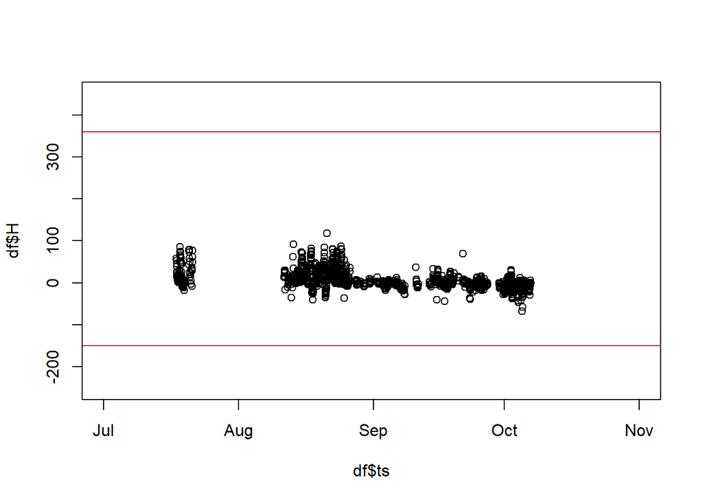

```r
plot(df$ts,df$H,ylim = c(-250,450));abline(h=-150, col= 'red');abline(h=360, col='red')
```

Clean based on graphs, create new variable (H.limits), and see cleaned product

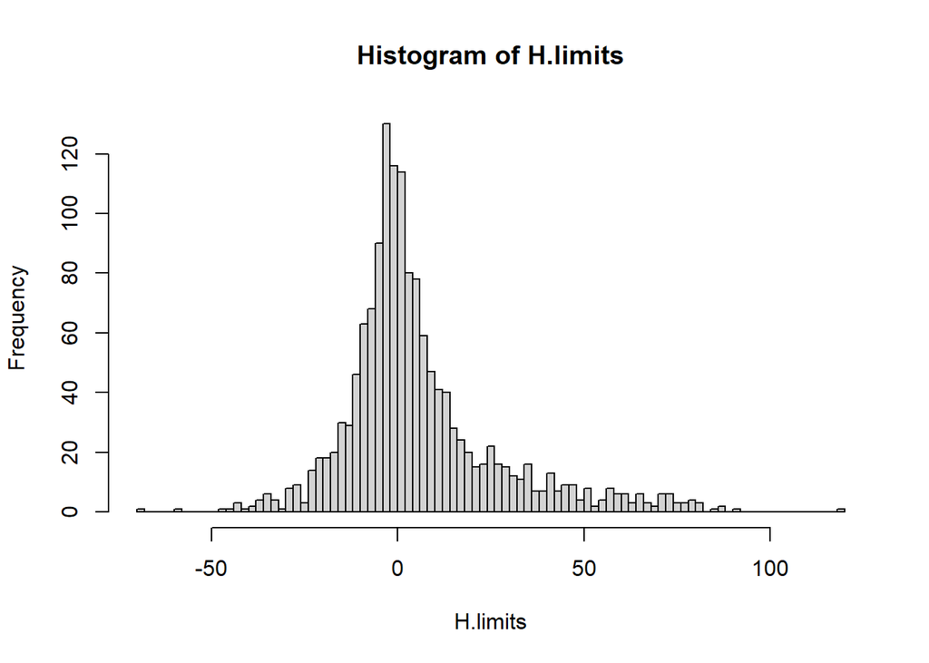

```r
H.limits = replace(df$H, df$H < -150 | df$H > 360,NA)
hist(H.limits,breaks = 100)
```

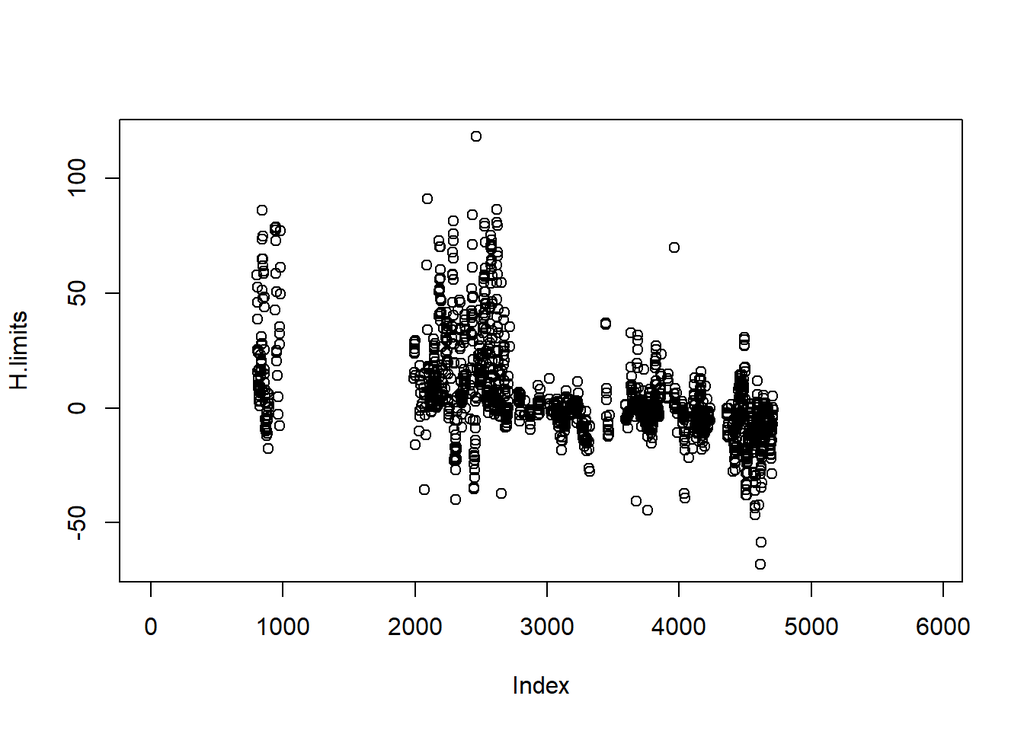

```r
plot(H.limits)
```

### LE

Plot LE Histogram and what we might clean

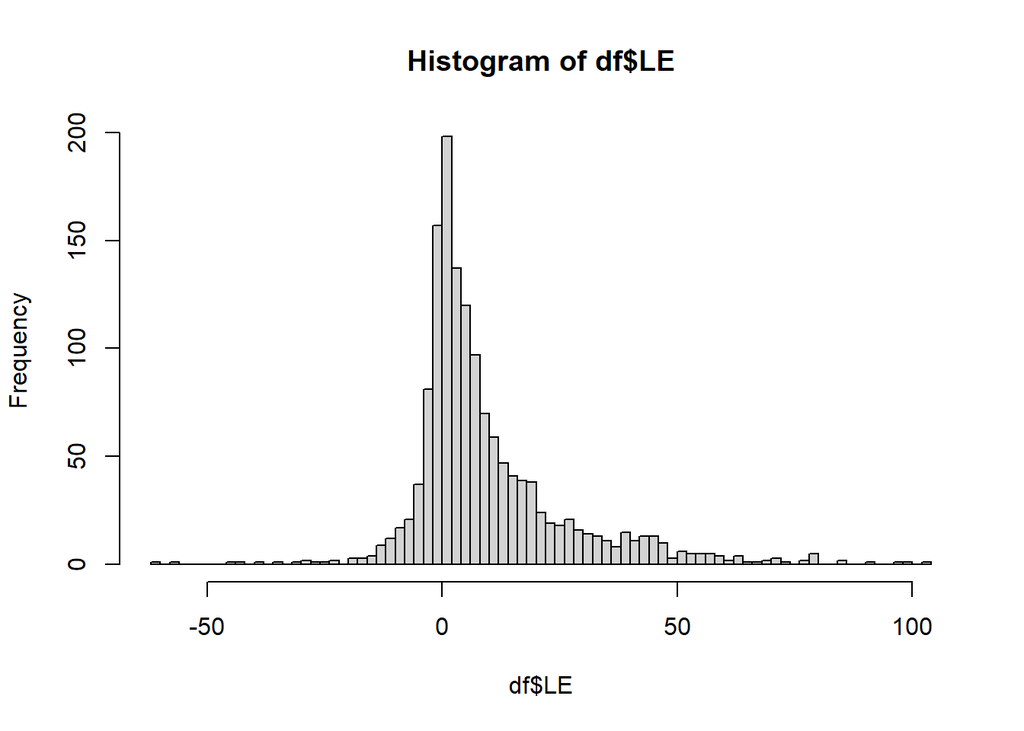

```r
hist(df$LE,breaks=100)
```

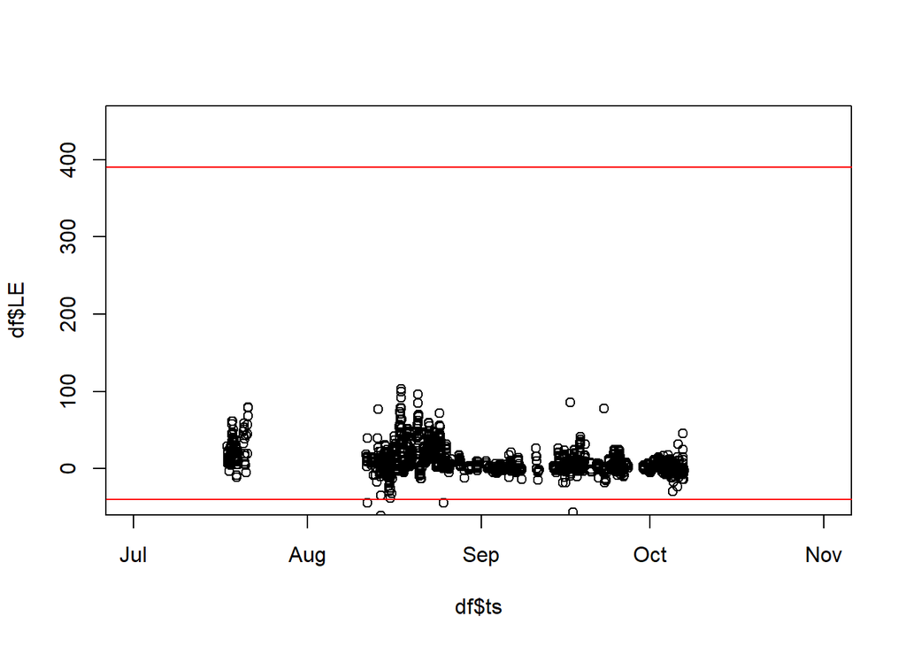

```r
plot(df$ts,df$LE,ylim = c(-40,450));abline(h=-40, col= 'red');abline(h=390, col='red')
```

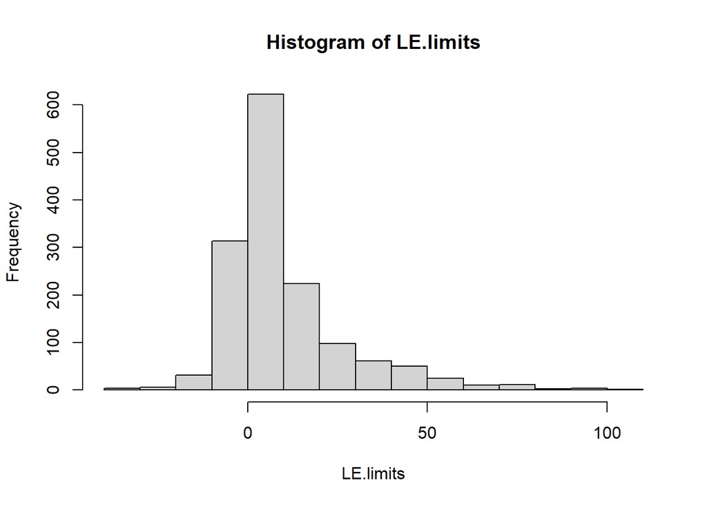

```r
LE.limits = replace(df$LE, df$LE < -40 | df$LE > 390,NA)
hist(LE.limits)
```

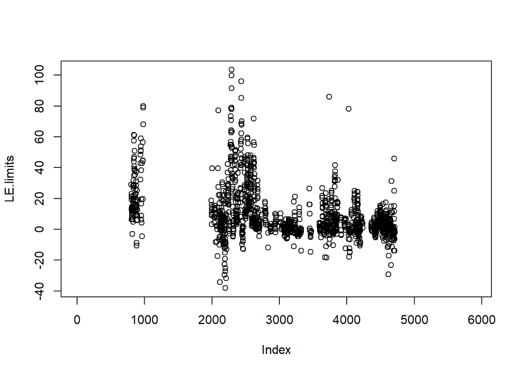

```r
plot(LE.limits)
```

## USTAR

use night-time only flux values and plot Ustar based on data drop off

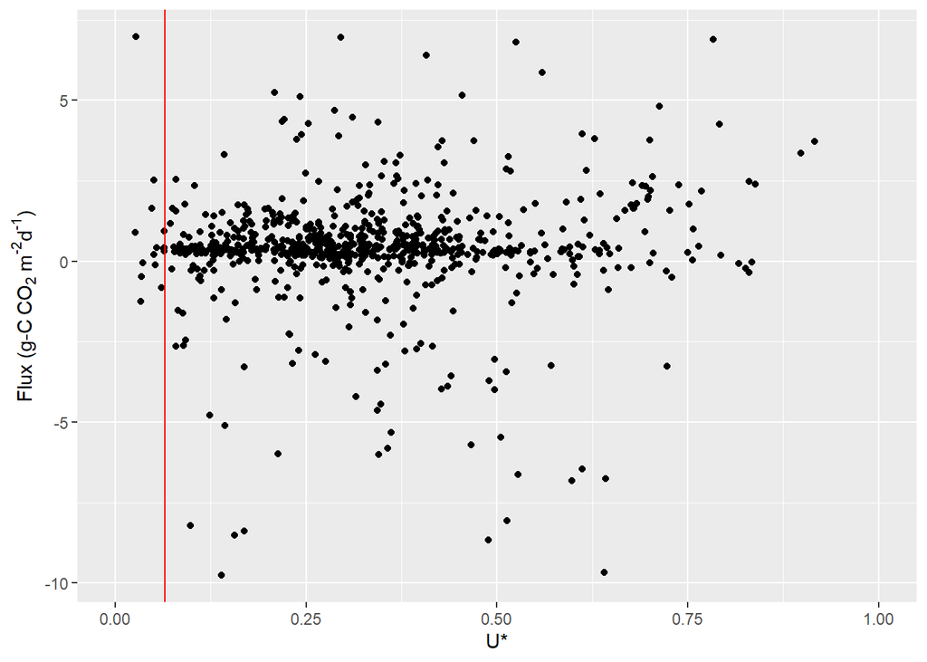

```r
df$nightCO2 = co2_flux.limits
df$nightCO2 = replace(df$nightCO2,df$SWIN_6_10_1_1_1 > 5,NA)

Uthreshold=0.065
ggplot(data = df,aes(`u*`,nightCO2))+
  ylab(expression(paste("Flux (g-C", ~CO[2], ~"m",""^"-2","d",""^"-1",")")))+
  geom_point()+xlab("U*")+
  scale_x_continuous(limits = c(0,1))+
  geom_vline(xintercept = Uthreshold,col='red')
```

pick threshold and filter based on plots above, I liked .065

created flag to indicate where u* values are below our threshold- makes cleaning with u* optional but easy when using cleaned data sets

```r
df$u_flag = ifelse(df$`u*` < Uthreshold,1,0)
```

## Combine Cleaning

investigate the previous limits and combine all to create a new variable (clean), plot to see difference

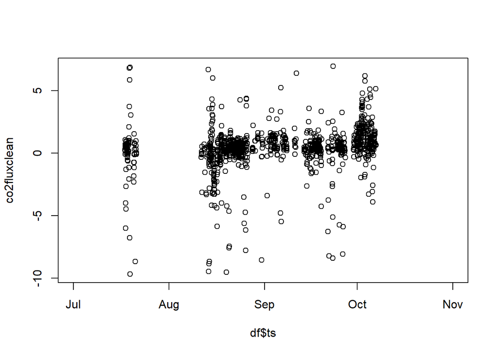

```r
co2fluxclean = ifelse(is.na(co2_flux.qc) | is.na(co2_flux.limits),NA,df$co2_flux)

ch4fluxclean = ifelse(is.na(ch4_flux.qc) | is.na(ch4_flux.limits),NA,df$ch4_flux)

Hclean = ifelse(is.na(H.qc) | is.na(H.limits),NA,df$H)

LEclean = ifelse(is.na(LE.qc) | is.na(LE.limits),NA,df$LE)

Tauclean = ifelse(is.na(Tau.qc) | is.na(Tau.limits),NA,df$Tau)

plot(df$ts,co2fluxclean)
```

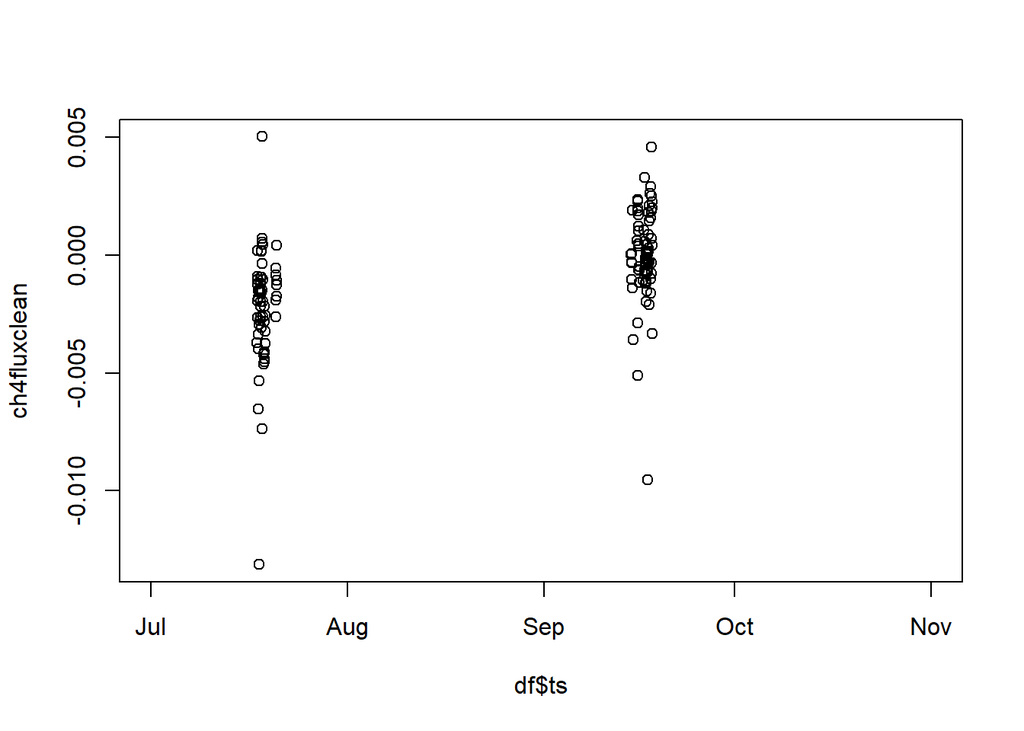

```r
plot(df$ts,ch4fluxclean)
```

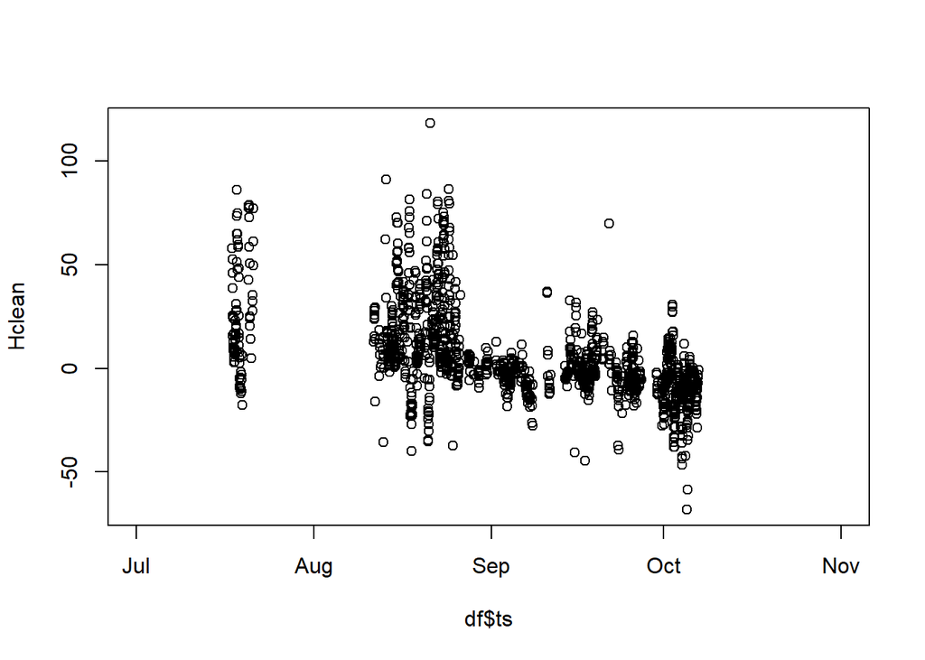

```r
plot(df$ts,Hclean)
```

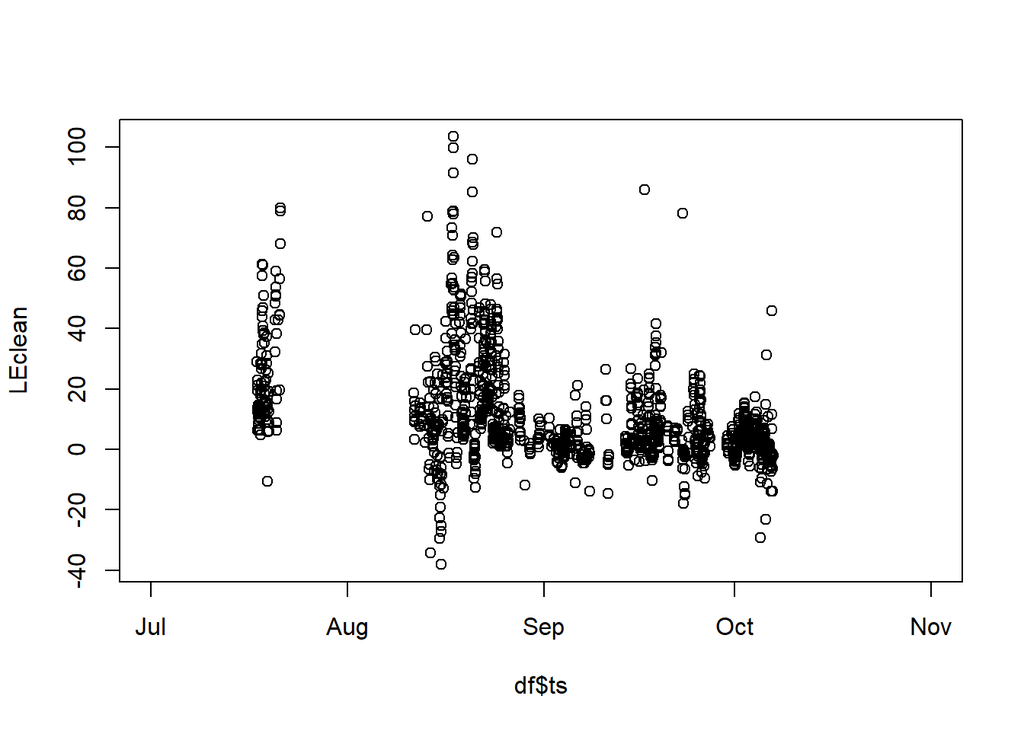

```r
plot(df$ts,LEclean)
```

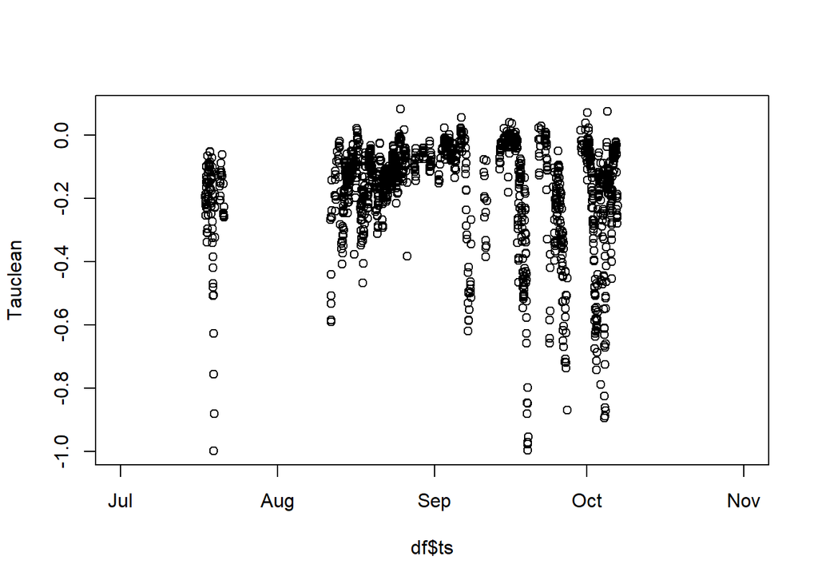

```r
plot(df$ts,Tauclean)
```

Add cleaned tau to dataframe (no MAD filter)

```r
df$Tau.c = Tauclean
```